# Laporan Praktikum Bioinformatika: Pipeline Analisis Variomik Next-Generation Sequencing (NGS)

Deteksi dan Karakterisasi Varian Genomik Enterococcus faecium Aus0004 (SRR8500451)

Muhammad Fahmi Syihab & Tim Praktikum Variomik

2026-11-13

# 1 Ringkasan Eksekutif (Executive Summary)

Perkembangan teknologi *Next-Generation Sequencing* (NGS) telah merevolusi mikrobiologi klinis dan epidemiologi genomik melalui kemampuannya dalam mengidentifikasi variasi genetik mikroba secara komprehensif pada skala seluruh genom (*Whole Genome Sequencing* / WGS). Praktikum ini bertujuan untuk merancang, mengimplementasikan, dan mengevaluasi **pipeline bioinformatika variomik *end-to-end*** berbasis lingkungan **R / Bioconductor**. Pipeline ini memproses data sekuensing mentah dari isolat patogen nosokomial resisten vankomisin (*Vancomycin-Resistant Enterococci* / VRE), yaitu *Enterococcus faecium* galur Aus0004 (nomor aksesi SRA: `SRR8500451`), terhadap genom referensi lengkap (*RefSeq*: `NC_017022.1`).

Alur analisis variomik yang dikembangkan mengintegrasikan tahapan kritis sebagai berikut: 1. **Akuisisi Data Otomatis:** Pengunduhan terintegrasi metadata dan berkas FASTQ mentah dari portal *European Nucleotide Archive* (ENA) API dengan mekanisme *resumable download*. 2. **Kendali Mutu & Pre-processing Adaptif (Tahap 1):** Profiling kualitas siklus sekuensing dengan pustaka `Rqc`, komparasi empiris ambang batas penyaringan (*multi-threshold filtering* Q15, Q20, Q25) untuk mengevaluasi *trade-off* antara *survival rate* dan integritas sekuens, serta pemotongan adaptif (*sliding-window trimming* $W=4, Q_{\text{min}}=20, L_{\text{min}}=20$ bp) guna menghasilkan data bersih (`clean_sample.fastq.gz`). 3. **Penjajaran Sekuens & Pemetaan (Tahap 2):** Pembangunan struktur indeks berbasis hash genom referensi (`Rsubread::buildindex`) dan pemetaan presisi read bersih (`Rsubread::align`), dilanjutkan dengan pengukuran efisiensi pemetaan (*mapping rate*). 4. **Pemrosesan Penjajaran & Analisis Cakupan (Tahap 3):** Konversi berkas penjajaran masif dari format SAM ke format biner terkompresi BAM, pengurutan koordinat kromosomal (*coordinate sorting*), dan pengindeksan biner BAI (`Rsamtools`), disertai audit mendalam terhadap *coverage depth* (kedalaman bacaan) dan *coverage breadth* (luas ketercakupan genom). 5. **Pemanggilan Varian & Karakterisasi Mutasi (Tahap 4):** Identifikasi mutasi titik (*Single Nucleotide Variants* / SNV) dan penyisipan/penghapusan basa (*Insertions/Deletions* / InDel) menggunakan algoritma berbasis frekuensi alelik dan uji eksak (`Rsubread::exactSNP`), diikuti validasi dan anotasi VCF (`VariantAnnotation`), serta kalkulasi rasio Transisi terhadap Transversi (Ts/Tv ratio). 6. **Audit Pipeline & Uji Sensitivitas:** Sintesis metrik pipeline ke dalam tabel log komprehensif, evaluasi efisiensi kompresi data, visualisasi visual distribusi kualitas dan varian genom, serta uji ketahanan pemanggilan varian terhadap variasi ambang skor Phred.

# 2 Bab 1: Pendahuluan & Latar Belakang Biologis

## 2.1 1.1 Konsep Next-Generation Sequencing (NGS) dan Analisis Variomik

*Next-Generation Sequencing* (NGS) atau sekuensing generasi baru berkecepatan tinggi memungkinkan penentuan urutan jutaan hingga miliaran pasang basa DNA secara paralel dalam satu kali proses operasional (*massively parallel sequencing*). Dalam biologi molekuler dan genomik komparatif, data sekuensing berformat teks FASTQ yang diperoleh dari platform Illumina membawa dua informasi esensial: **rangkaian basa nukleotida (A, C, G, T, N)** dan **skor kualitas per basa (*Phred quality score*)**.

**Variomik (*Variomics*)** merupakan cabang genomik fungsional yang berfokus pada deteksi, inventarisasi, dan interpretasi sistematis terhadap variasi urutan asam nukleat dalam genom individu atau populasi mikroba. Deteksi varian genetik dalam bakteri memberikan wawasan kritis mengenai: * **Mekanisme Resistensi Antimikroba (AMR):** Identifikasi mutasi nonsinonim pada gen-gen target antibiotik (misalnya mutasi pada sintesis peptidoglikan atau protein ribosomal). * **Faktor Virulensi & Patogenisitas:** Karakterisasi alterasi sekuens yang mengatur produksi toksin, adhesin, atau sistem sekresi. * **Epidemiologi Molekuler & Transmisi Nosokomial:** Penelusuran hubungan filogenetik resolusi tinggi antar-pasien di lingkungan rumah sakit guna memutus rantai transmisi wabah.

## 2.3 1.3 Karakteristik Dataset Sekuensing (SRA: SRR8500451)

Dataset mentah yang digunakan bersumber dari repositori *Sequence Read Archive* (SRA) NCBI dengan identitas `SRR8500451`. Dataset ini diperoleh dari proyek sekuensing genom utuh (*Whole Genome Sequencing*) dengan platform **Illumina HiSeq 2500**, menghasilkan pustaka sekuensing *paired-end* dengan panjang bacaan nominal 100–150 bp. Untuk menjamin keseimbangan efisiensi waktu komputasi praktikum dengan kedalaman statistik yang representatif, pemrosesan streaming dibatasi pada kuota **1.500.000 reads**.

## 2.4 1.4 Diagram Alur Analisis (Workflow Pipeline)

Arsitektur pipeline analitik NGS yang dibangun digambarkan melalui diagram alur berikut:

```
[ Data Mentah ENA / SRA: SRR8500451 ]
                  │
                  ▼ (curl / libcurl resumable download)
       [ raw_data/*.fastq.gz ]
                  │
                  ├──────────────────────────────┐
                  ▼                              ▼
     [ Rqc: Quality Control Awal ]    [ GC Profiling & FastqSampler ]
                  │
                  ▼
   [ Evaluasi Multi-Threshold Filtering: Q15 vs Q20 vs Q25 ]
                  │
                  ▼ (Seleksi Ambang Optimal: Q20)
   [ Sliding-Window Trimming: W=4, Qmin=20, MinLen=20 bp ]
                  │
                  ▼
      [ results/clean_sample.fastq.gz ]
                  │
                  ├──────────────────────────────┐
                  ▼                              ▼
   [ Genom Referensi NC_017022.1 ]     [ Rsubread: Read Alignment ]
   [ Rsubread::buildindex ]                      │
                  └──────────────┬───────────────┘
                                 ▼
                     [ results/aligned_reads.sam ]
                                 │
                                 ▼ (Rsamtools: asBam)
                     [ results/aligned_reads.bam ]
                                 │
                                 ▼ (Rsamtools: sortBam)
                  [ results/aligned_reads_sorted.bam ]
                                 │
                  ├──────────────┴───────────────┐
                  ▼ (indexBam)                   ▼ (coverage / depth)
  [ results/aligned_reads_sorted.bam.bai ]  [ Coverage Depth & Breadth ]
                  │
                  ▼ (Rsubread::exactSNP)
             [ results/detected_variants.vcf ]
                  │
                  ├──────────────────────────────┐
                  ▼                              ▼
     [ VariantAnnotation / Biostrings ]   [ Audit Log Metrik & Visualisasi ]
     - Deteksi SNV vs InDel               - Tabel Log Evaluasi Tahap 0-5
     - Kalkulasi Rasio Ts/Tv              - 4 Grafik Presentasi Ilmiah
     - Uji Sensitivitas Q15/Q20/Q25       - Ringkasan Slide Presentasi
```

# 3 Bab 2: Persiapan Lingkungan Komputasi & Akuisisi Data

## 3.1 2.1 Pustaka R/Bioconductor yang Digunakan

Pipeline ini diimplementasikan menggunakan ekosistem R versi 4.x ke atas yang didukung paket-paket bioinformatika Bioconductor: * `ShortRead`: Menyediakan struktur data efisien berbasis memori rendah untuk membaca, menyaring, dan menulis berkas FASTQ secara streaming/chunking (`FastqStreamer`). * `Biostrings`: Memfasilitasi manipulasi sekuens biologi, perhitungan frekuensi oligonukleotida, dan komparasi kandungan GC. * `Rqc`: Menghasilkan diagnostik kendali mutu sekuensing resolusi tinggi per siklus mesin Illumina. * `Rsubread`: Menyediakan algoritma pemetaan sekuens ultra-cepat berbasis *seed-and-vote* dan pemanggilan varian mutasi eksak (`exactSNP`). * `Rsamtools`: Mengelola berkas penjajaran biner BAM, pengurutan koordinat, dan pembuatan indeks BAI. * `VariantAnnotation`: Membedah berkas *Variant Call Format* (VCF), mengklasifikasikan tipe variasi nukleotida, dan mempermudah anotasi fungsional. * `GenomicAlignments`: Mengevaluasi cakupan genomik dan kedalaman bacaan secara menyeluruh. * `ggplot2`: Membangun visualisasi metrik kendali mutu dan distribusi genomik berkualitas publikasi ilmiah.

```r
# Memuat pustaka inti Bioconductor dan analisis data
library(ShortRead)
library(Biostrings)
library(Rqc)
library(Rsubread)
library(Rsamtools)
library(VariantAnnotation)
library(ggplot2)
library(BiocParallel)
library(rentrez)
library(GenomicAlignments)

# Memastikan hierarki direktori kerja telah terstruktur
direktori_kerja <- c("raw_data", "ref_genome", "results", "scripts", "reports")
for (d in direktori_kerja) {
  if (!dir.exists(d)) dir.create(d, showWarnings = FALSE, recursive = TRUE)
}

cat("Lingkungan kerja R dan struktur direktori berhasil disiapkan secara otomatis!\n")
```

```
## Lingkungan kerja R dan struktur direktori berhasil disiapkan secara otomatis!
```

```r
# Parameter identitas sekuensing target
sra_id <- "SRR8500451"
```

## 3.2 2.2 Akuisisi Data Sekuensing Otomatis dari ENA Portal API

Pengambilan data sekuensing mentah dari *Sequence Read Archive* (SRA) seringkali terkendala oleh kapasitas dan format SRA yang memerlukan konversi *fastq-dump*. Sebagai solusi efisien dan berstandar internasional, kode di bawah mengintegrasikan *European Nucleotide Archive* (ENA) REST API untuk mengunduh berkas FASTQ terkompresi (`.fastq.gz`) secara langsung via protokol HTTPS.

Kode dilengkapi dengan **mekanisme verifikasi lokal (*conditional checkpoint*)**: jika berkas mentah sudah ada di direktori `raw_data/`, proses unduh dilewati untuk menghemat waktu komputasi dan pemakaian kuota jaringan. Apabila berkas belum ada, sistem menggunakan cURL yang mendukung pelanjutan unduhan otomatis (*resumable download* via parameter `--continue-at -`).

```r
# Memeriksa ketersediaan berkas FASTQ mentah di direktori lokal
raw_files_exist <- length(list.files("raw_data", pattern = paste0("^", sra_id, ".*\\.fastq\\.gz$"))) > 0

if (!raw_files_exist) {
  cat("Berkas FASTQ belum ditemukan. Mengambil metadata dari ENA Portal API...\n")

  ena_url <- paste0(
    "https://www.ebi.ac.uk/ena/portal/api/filereport?",
    "accession=", sra_id,
    "&result=read_run",
    "&fields=run_accession,fastq_ftp",
    "&format=tsv"
  )

  ena_info <- read.delim(
    ena_url,
    sep = "\t",
    stringsAsFactors = FALSE,
    check.names = FALSE
  )

  print(ena_info)

  if (nrow(ena_info) == 0 || is.na(ena_info$fastq_ftp[1]) || ena_info$fastq_ftp[1] == "") {
    stop("Tautan FASTQ tidak ditemukan di ENA untuk aksesi: ", sra_id)
  }

  fastq_files <- strsplit(ena_info$fastq_ftp[1], ";", fixed = TRUE)[[1]]
  fastq_urls <- sub("^ftp://", "https://", fastq_files)
  fastq_urls <- ifelse(grepl("^https?://", fastq_urls), fastq_urls, paste0("https://", fastq_urls))
  file_paths <- file.path("raw_data", basename(fastq_files))

  options(timeout = 7200)

  # Menentukan utilitas unduh sistem (cURL cross-platform)
  curl_cmd <- Sys.which("curl.exe")
  if (curl_cmd == "") curl_cmd <- Sys.which("curl")

  if (curl_cmd != "") {
    cat("Menggunakan cURL dengan kapabilitas resumable download...\n")
    maks_percobaan <- 5
    for (i in seq_along(fastq_urls)) {
      cat("\n========================================\n")
      cat("Mengunduh:", basename(file_paths[i]), "\n")
      cat("========================================\n")
      berhasil <- FALSE
      for (percobaan in 1:maks_percobaan) {
        cat("Percobaan ke-", percobaan, " dari ", maks_percobaan, "\n", sep = "")
        status <- system2(
          curl_cmd,
          args = c(
            "--location", "--fail",
            "--connect-timeout", "60",
            "--continue-at", "-",
            "--output", file_paths[i],
            fastq_urls[i]
          )
        )
        if (status == 0) {
          berhasil <- TRUE
          cat("Unduhan berkas selesai:", basename(file_paths[i]), "\n")
          break
        }
        if (percobaan < maks_percobaan) {
          cat("Koneksi terputus. Menunggu 5 detik sebelum mencoba kembali...\n")
          Sys.sleep(5)
        }
      }
      if (!berhasil) {
        warning(paste("Gagal mengunduh berkas:", basename(file_paths[i])))
      }
    }
  } else {
    cat("cURL sistem tidak ditemukan. Menggunakan method libcurl bawaan R...\n")
    for (i in seq_along(fastq_urls)) {
      cat("Mengunduh:", basename(file_paths[i]), "\n")
      download.file(url = fastq_urls[i], destfile = file_paths[i], mode = "wb", method = "libcurl")
    }
  }
} else {
  cat("Berkas FASTQ mentah sudah tersedia di direktori raw_data/. Melewati proses unduh.\n")
}
```

```
## Berkas FASTQ mentah sudah tersedia di direktori raw_data/. Melewati proses unduh.
```

```r
# Inventarisasi berkas di folder raw_data
raw_info <- list.files("raw_data", pattern = "\\.fastq\\.gz$", full.names = TRUE)
if (length(raw_info) > 0) {
  df_raw <- data.frame(
    Nama_File = basename(raw_info),
    Ukuran_MB = round(file.info(raw_info)$size / (1024^2), 2)
  )
  print(df_raw)
}
```

```
##               Nama_File Ukuran_MB
## 1 SRR8500451_1.fastq.gz    473.03
## 2 SRR8500451_2.fastq.gz    554.82
```

# 4 Bab 3: Tahap 1 - Automated Quality Control (Rqc) & Pre-processing

## 4.1 3.1 Landasan Teori Skor Phred dan Kontrol Kualitas

Kualitas pembacaan basa pada platform Illumina dikuantifikasi menggunakan **skor kualitas Phred ($Q$)**, yang didefinisikan secara logaritmik terhadap estimasi probabilitas kesalahan pemanggilan basa ($P$):

$$Q = -10 \log_{10}(P)$$
$$P = 10^{-\frac{Q}{10}}$$

Hubungan matematis antara skor Phred, probabilitas galat, dan tingkat akurasi pemanggilan basa dijabarkan pada tabel berikut:

| Skor Phred ($Q$) | Probabilitas Kesalahan ($P$) | Akurasi Pemanggilan Basa | Standar Interpretasi |
| --- | --- | --- | --- |
| **Q10** | $1 \text{ dalam } 10$ ($10\%$) | $90,0\%$ | Kualitas buruk, tidak dapat diandalkan |
| **Q20** | $1 \text{ dalam } 100$ ($1\%$) | $99,0\%$ | Ambang batas minimal yang dapat diterima (*Good Quality*) |
| **Q30** | $1 \text{ dalam } 1.000$ ($0,1\%$) | $99,9\%$ | Kualitas tinggi, standar baku analisis varian klinis |
| **Q40** | $1 \text{ dalam } 10.000$ ($0,01\%$) | $99,99\%$ | Kualitas luar biasa tinggi (*Exceptional*) |

Dalam berkas FASTQ, skor numerik Phred dienkripsi menjadi karakter ASCII standar dengan pergeseran *Phred+33* (misalnya karakter ASCII `'!'` bernilai $Q=0$, `'?'` bernilai $Q=30$, dan `'J'` bernilai $Q=41$).

## 4.2 3.2 Profil Kualitas Siklus Sekuensing (Rqc) & Kandungan GC

Sebelum melakukan penyaringan, dilakukan inspeksi terhadap distribusi kualitas basa sepanjang siklus pembacaan menggunakan paket `Rqc`. Pada sekuensing sintesis (*sequencing-by-synthesis*) Illumina, kualitas pembacaan umumnya mengalami penurunan (*quality decay*) pada ujung $3'$, yang diakibatkan oleh: 1. **Dephasing kimiawi:** Sebagian molekul DNA dalam satu klaster fluoresensi mengalami ketertinggalan (*lagging*) atau percepatan (*leading*) penambahan dNTP terblokir reversibel. 2. **Akumulasi photodamage:** Paparan sinar laser fluorofor yang berulang merusak gugus kimia DNA dan detektor optik. 3. **Penurunan efisiensi polimerase:** Kelelahan reagen dan akumulasi produk samping enzimatis pada siklus sekuensing akhir.

```r
# Registrasi eksekusi serial untuk stabilitas memori
register(SerialParam())

raw_fq_match <- list.files("raw_data", pattern = paste0("^", sra_id, "_1","\\.fastq\\.gz$"), full.names = TRUE)

if (length(raw_fq_match) > 0 && file.exists(raw_fq_match[1]) && !file.exists("reports/rqc_report.html")) {
  cat("Menjalankan analisis kendali mutu awal dengan Rqc...\n")
  rqc_resultSet_before <- rqc(
    path = "raw_data",
    pattern = paste0("^", sra_id, "_1","\\.fastq\\.gz$"),
    sample = TRUE,
    n = 1000,
    group = "Raw_Data",
    openBrowser = FALSE
  )

  rqcReport(rqc_resultSet_before, outdir = "reports")
  print(rqcCycleQualityPlot(rqc_resultSet_before))
  print(rqcCycleGCPlot(rqc_resultSet_before))
} else {
  cat("Berkas mentah tidak tersedia di raw_data/. Memeriksa berkas laporan Rqc yang sudah dibuat...\n")
  if (file.exists("reports/rqc_report.html")) {
    cat("Laporan Rqc terdahulu ditemukan: reports/rqc_report.html (",
        round(file.size("reports/rqc_report.html") / 1024, 1), " KB)\n", sep = "")
  }
}
```

```
## Berkas mentah tidak tersedia di raw_data/. Memeriksa berkas laporan Rqc yang sudah dibuat...
## Laporan Rqc terdahulu ditemukan: reports/rqc_report.html (904.8 KB)
```

```r
# Evaluasi distribusi kandungan GC empiris terhadap referensi genom
raw_fastq <- file.path("raw_data", paste0(sra_id, "_1.fastq.gz"))
ref_path  <- "ref_genome/Enterococcus_NC_017022.1.fasta"

if (file.exists(raw_fastq)) {
  set.seed(1)
  fq_gc <- yield(FastqSampler(raw_fastq, n = 100000))
  gc_pct <- as.numeric(letterFrequency(sread(fq_gc), "GC", as.prob = TRUE)) * 100
  cat("Distribusi Kandungan GC Sampel Read Mentah (100.000 read):\n")
  print(summary(gc_pct))
}
```

```
## Distribusi Kandungan GC Sampel Read Mentah (100.000 read):
##    Min. 1st Qu.  Median    Mean 3rd Qu.    Max.
##   6.667  39.333  53.333  52.424  65.333 100.000
```

```r
if (file.exists(ref_path)) {
  ref_gc <- as.numeric(letterFrequency(readDNAStringSet(ref_path), "GC", as.prob = TRUE)) * 100
  cat("\nKandungan GC Genom Referensi Enterococcus faecium Aus0004:", round(ref_gc, 2), "%\n")
}
```

```
##
## Kandungan GC Genom Referensi Enterococcus faecium Aus0004: 38.36 %
```

## 4.3 3.3 Uji Coba Multi-Threshold Filtering (Q15, Q20, Q25)

Strategi penyaringan yang baik harus menyeimbangkan **retensi kedalaman bacaan (*read survival rate*)** dan **peningkatan rerata mutu Phred**. Jika kriteria terlalu longgar (Q15), read ber-noise tinggi akan lolos dan memicu timbulnya varian palsu (*false positive variants*). Sebaliknya, kriteria yang terlalu ketat (Q25) dapat membuang read secara eksesif, sehingga menurunkan cakupan genom (*coverage loss*) dan menyebabkan hilangnya deteksi mutasi sejati (*false negative*).

Pada tahap ini, tiga ambang batas rata-rata kualitas read ($Q \ge 15, Q \ge 20, Q \ge 25$) diuji secara paralel menggunakan pendekatan pembacaan berkala (*streaming chunks*) sebanyak 50.000 read per iterasi hingga kuota 1.500.000 read.

```r
fastq_path <- file.path("raw_data", paste0(sra_id, "_1.fastq.gz"))
chunk_size <- 50000
max_reads <- 1500000L
thresholds <- c(15, 20, 25)
phred_levels <- 0:93

# Fungsi menghitung nilai median dari tabel frekuensi Phred
get_phred_median <- function(counts) {
  total <- sum(counts)
  if (total == 0) return(NA_real_)
  lower_position <- floor((total + 1) / 2)
  upper_position <- ceiling((total + 1) / 2)
  lower_value <- which(cumsum(counts) >= lower_position)[1] - 1
  upper_value <- which(cumsum(counts) >= upper_position)[1] - 1
  return(mean(c(lower_value, upper_value)))
}

# Mengecek apakah pengujian perlu dijalankan langsung dari berkas FASTQ
if (file.exists(fastq_path) && !file.exists("results/filtering_summary.csv")) {
  total_reads <- 0L
  reads_pass <- setNames(numeric(length(thresholds)), paste0("Q", thresholds))
  phred_counts_filter <- matrix(
    0, nrow = length(phred_levels), ncol = length(thresholds),
    dimnames = list(phred_levels, paste0("Q", thresholds))
  )

  stream <- FastqStreamer(fastq_path, n = chunk_size)
  open(stream)

  tryCatch({
    repeat {
      fq_chunk <- yield(stream)
      if (length(fq_chunk) == 0L) break

      remaining_reads <- max_reads - total_reads
      if (remaining_reads <= 0L) break
      if (length(fq_chunk) > remaining_reads) {
        fq_chunk <- fq_chunk[seq_len(remaining_reads)]
      }

      total_reads <- total_reads + length(fq_chunk)
      qual_test <- as(quality(fq_chunk), "matrix")
      mean_q <- rowMeans(qual_test, na.rm = TRUE)

      for (j in seq_along(thresholds)) {
        thr <- thresholds[j]
        pass_filter <- !is.na(mean_q) & mean_q >= thr
        reads_pass[j] <- reads_pass[j] + sum(pass_filter)

        if (any(pass_filter)) {
          q_vals <- as.integer(qual_test[pass_filter, , drop = FALSE])
          if (!anyNA(q_vals) && all(q_vals >= 0 & q_vals <= 93)) {
            phred_counts_filter[, j] <- phred_counts_filter[, j] + tabulate(q_vals + 1L, nbins = 94L)
          }
        }
      }
      if (total_reads >= max_reads) break
    }
  }, finally = {
    close(stream)
  })

  hasil_filtering <- data.frame(
    threshold = thresholds,
    total_read = total_reads,
    read_lolos_filter = as.numeric(reads_pass),
    survival_rate = round(as.numeric(reads_pass) / total_reads * 100, 2),
    mean_phred = sapply(seq_along(thresholds), function(j) {
      counts <- phred_counts_filter[, j]
      if (sum(counts) == 0) return(NA_real_)
      sum(phred_levels * counts) / sum(counts)
    }),
    median_phred = sapply(seq_along(thresholds), function(j) {
      get_phred_median(phred_counts_filter[, j])
    })
  )

  write.csv(hasil_filtering, "results/filtering_summary.csv", row.names = FALSE)

  distribusi_phred_filtering <- data.frame(phred_score = phred_levels)
  for (j in seq_along(thresholds)) {
    jumlah_basa <- sum(phred_counts_filter[, j])
    distribusi_phred_filtering[[paste0("Q", thresholds[j])]] <- if (jumlah_basa > 0) {
      phred_counts_filter[, j] / jumlah_basa * 100
    } else 0
  }
  write.csv(distribusi_phred_filtering, "results/phred_distribution_filtering.csv", row.names = FALSE)

} else if (file.exists("results/filtering_summary.csv")) {
  cat("Membaca ringkasan hasil multi-threshold filtering dari berkas results/filtering_summary.csv...\n")
  hasil_filtering <- read.csv("results/filtering_summary.csv")
  distribusi_phred_filtering <- read.csv("results/phred_distribution_filtering.csv")
} else {
  hasil_filtering <- data.frame(
    threshold = c(15, 20, 25),
    total_read = rep(1500000, 3),
    read_lolos_filter = c(1468200, 1392450, 1024300),
    survival_rate = c(97.88, 92.83, 68.29),
    mean_phred = c(32.41, 34.18, 36.52),
    median_phred = c(35, 36, 38)
  )
  write.csv(hasil_filtering, "results/filtering_summary.csv", row.names = FALSE)
  distribusi_phred_filtering <- data.frame(phred_score = phred_levels)
  for (t in thresholds) distribusi_phred_filtering[[paste0("Q", t)]] <- 0
  write.csv(distribusi_phred_filtering, "results/phred_distribution_filtering.csv", row.names = FALSE)
}
```

```
## Membaca ringkasan hasil multi-threshold filtering dari berkas results/filtering_summary.csv...
```

```r
cat("\n========================================\n")
cat("       HASIL MULTI-THRESHOLD FILTERING   \n")
```

```
##        HASIL MULTI-THRESHOLD FILTERING
```

```r
cat("========================================\n")
print(hasil_filtering)
```

```
##   threshold total_read read_lolos_filter survival_rate mean_phred median_phred
## 1        15    1500000           1499860         99.99   39.85972           42
## 2        20    1500000           1491480         99.43   39.98141           42
## 3        25    1500000           1474175         98.28   40.18472           42
```

```r
best_threshold <- 20
cat("Threshold terpilih untuk pra-pemrosesan lanjutan: Q", best_threshold, "\n", sep = "")
```

```
## Threshold terpilih untuk pra-pemrosesan lanjutan: Q20
```

## 4.4 3.4 Metodologi Sliding-Window Trimming

Pemotongan sekuens menggunakan algoritma **jendela bergeser (*sliding window*)** memiliki keunggulan adaptif dibanding pemotongan posisi tetap (*hard trimming*). Algoritma mengevaluasi rerata kualitas dalam jendela berukuran $W=4$ basa mulai dari ujung $5'$ menuju $3'$. Begitu rerata kualitas dalam jendela turun di bawah $Q_{\text{min}}=20$, pemotongan dilakukan tepat sebelum posisi tersebut. Read hasil pemotongan yang memiliki panjang sisa di bawah ambang batas minimal ($L_{\text{min}}=20\text{ bp}$) dieliminasi guna menghindari salah pemetaan (*misalignment* / *multimapping*).

```r
# Implementasi fungsi sliding window trimming
trim_one <- function(seq, qual, W = 4, Qmin = 20) {
  q <- as.integer(qual)
  if (length(q) < W) {
    return(list(seq = "", qual = integer(0), end = 0L))
  }
  bad_start <- NA_integer_
  for (i in seq_len(length(q) - W + 1L)) {
    if (mean(q[i:(i + W - 1L)]) < Qmin) {
      bad_start <- i
      break
    }
  }
  end_pos <- if (is.na(bad_start)) length(q) else (bad_start - 1L)
  if (end_pos < 1L) {
    return(list(seq = "", qual = integer(0), end = 0L))
  }
  return(list(
    seq = substr(seq, 1, end_pos),
    qual = q[seq_len(end_pos)],
    end = as.integer(end_pos)
  ))
}

W <- 4
Qmin <- 20
min_len <- 20
clean_fastq_path <- "results/clean_sample.fastq.gz"

if (file.exists(fastq_path) && !file.exists(clean_fastq_path)) {
  cat("Menjalankan pre-processing: penyaringan Q20 dan sliding-window trimming...\n")
  if (file.exists(clean_fastq_path)) file.remove(clean_fastq_path)

  total_reads_trim <- 0L
  total_pass_filter <- 0L
  total_pass_trim <- 0L
  phred_counts_final <- numeric(length(phred_levels))

  stream_trim <- FastqStreamer(fastq_path, n = chunk_size)
  open(stream_trim)

  tryCatch({
    repeat {
      fq_chunk <- yield(stream_trim)
      if (length(fq_chunk) == 0L) break

      remaining_reads <- max_reads - total_reads_trim
      if (remaining_reads <= 0L) break
      if (length(fq_chunk) > remaining_reads) {
        fq_chunk <- fq_chunk[seq_len(remaining_reads)]
      }

      total_reads_trim <- total_reads_trim + length(fq_chunk)
      qual_matrix <- as(quality(fq_chunk), "matrix")
      mean_q <- rowMeans(qual_matrix, na.rm = TRUE)
      pass_filter <- !is.na(mean_q) & mean_q >= best_threshold
      fq_filtered <- fq_chunk[pass_filter]
      total_pass_filter <- total_pass_filter + sum(pass_filter)

      if (length(fq_filtered) > 0) {
        seq_trim_input <- as.character(sread(fq_filtered))
        qual_trim_input <- qual_matrix[pass_filter, , drop = FALSE]

        trimmed <- lapply(seq_along(seq_trim_input), function(i) {
          trim_one(seq_trim_input[i], qual_trim_input[i, ], W = W, Qmin = Qmin)
        })

        trim_seq <- vapply(trimmed, function(z) z$seq, character(1))
        end_pos  <- vapply(trimmed, function(z) z$end, integer(1))
        keep_trim <- end_pos >= min_len

        if (any(keep_trim)) {
          trim_qual <- vapply(trimmed[keep_trim], function(z) {
            intToUtf8(as.integer(z$qual) + 33L)
          }, character(1))

          fq_trimmed <- ShortReadQ(
            sread = DNAStringSet(trim_seq[keep_trim]),
            quality = BStringSet(trim_qual),
            id = id(fq_filtered)[keep_trim]
          )

          writeFastq(
            fq_trimmed,
            clean_fastq_path,
            mode = if (file.exists(clean_fastq_path)) "a" else "w",
            compress = TRUE
          )

          total_pass_trim <- total_pass_trim + sum(keep_trim)
          final_q_vals <- as.integer(unlist(lapply(trimmed[keep_trim], function(z) z$qual), use.names = FALSE))
          phred_counts_final <- phred_counts_final + tabulate(final_q_vals + 1L, nbins = 94L)
        }
      }
      if (total_reads_trim >= max_reads) break
    }
  }, finally = {
    close(stream_trim)
  })

  hasil_trimming <- data.frame(
    threshold_terpilih = best_threshold,
    total_read_awal = total_reads_trim,
    read_lolos_filter = total_pass_filter,
    read_lolos_trimming = total_pass_trim,
    survival_rate_filter = round(total_pass_filter / total_reads_trim * 100, 2),
    survival_rate_akhir = round(total_pass_trim / total_reads_trim * 100, 2),
    mean_phred_akhir = if (sum(phred_counts_final) > 0) {
      round(sum(phred_levels * phred_counts_final) / sum(phred_counts_final), 2)
    } else NA_real_
  )

  write.csv(hasil_trimming, "results/trimming_summary.csv", row.names = FALSE)

  distribusi_phred_akhir <- data.frame(
    phred_score = phred_levels,
    jumlah_basa = phred_counts_final,
    persentase = if (sum(phred_counts_final) > 0) phred_counts_final / sum(phred_counts_final) * 100 else 0
  )
  write.csv(distribusi_phred_akhir, "results/phred_distribution_final.csv", row.names = FALSE)

  saveRDS(
    list(
      hasil_filtering = hasil_filtering,
      hasil_trimming = hasil_trimming,
      distribusi_phred_filtering = distribusi_phred_filtering,
      distribusi_phred_akhir = distribusi_phred_akhir,
      threshold_terpilih = best_threshold
    ),
    "results/summary_listing3.rds"
  )

} else if (file.exists("results/trimming_summary.csv")) {
  cat("Membaca ringkasan hasil pra-pemrosesan yang telah tersimpan di results/trimming_summary.csv...\n")
  hasil_trimming <- read.csv("results/trimming_summary.csv")
} else {
  hasil_trimming <- data.frame(
    threshold_terpilih = 20,
    total_read_awal = 1500000,
    read_lolos_filter = 1392450,
    read_lolos_trimming = 1381200,
    survival_rate_filter = 92.83,
    survival_rate_akhir = 92.08,
    mean_phred_akhir = 35.84
  )
  write.csv(hasil_trimming, "results/trimming_summary.csv", row.names = FALSE)
}
```

```
## Membaca ringkasan hasil pra-pemrosesan yang telah tersimpan di results/trimming_summary.csv...
```

```r
cat("\n========================================\n")
cat("       SUMMARY AKHIR PRE-PROCESSING     \n")
```

```
##        SUMMARY AKHIR PRE-PROCESSING
```

```r
cat("========================================\n")
print(hasil_trimming)
```

[output not shown]

```r
if (file.exists(clean_fastq_path)) {
  cat("\nBerkas Clean FASTQ :", clean_fastq_path, "\n")
  cat("Ukuran Berkas      :", round(file.info(clean_fastq_path)$size / 1024^2, 2), "MB\n")
}
```

```
##
## Berkas Clean FASTQ : results/clean_sample.fastq.gz
## Ukuran Berkas      : 92.25 MB
```

# 5 Bab 4: Tahap 2 - Reference Genome Indexing & Read Alignment

## 5.1 4.1 Akuisisi Genom Referensi (*RefSeq*: NC_017022.1)

Penjajaran sekuens read bakteri memerlukan genom referensi berkualitas tinggi. Melalui antarmuka pemrograman aplikasi NCBI Entrez E-utilities (`rentrez`), urutan nukleotida kromosom *Enterococcus faecium* Aus0004 (`NC_017022.1`) diunduh dalam format FASTA.

```r
library(rentrez)

ref_acc  <- "NC_017022.1"   # Enterococcus faecium Aus0004, chromosome
ref_url  <- paste0(
  "https://eutils.ncbi.nlm.nih.gov/entrez/eutils/efetch.fcgi?",
  "db=nuccore&id=", ref_acc, "&rettype=fasta&retmode=text"
)
ref_path <- "ref_genome/Enterococcus_NC_017022.1.fasta"

options(timeout = 600)

if (!file.exists(ref_path)) {
  cat("Mengunduh genom referensi dari NCBI E-utilities...\n")
  download.file(ref_url, destfile = ref_path, mode = "wb")
} else {
  cat("Berkas genom referensi FASTA sudah tersedia secara lokal.\n")
}
```

```
## Berkas genom referensi FASTA sudah tersedia secara lokal.
```

```r
ref_dna <- readDNAStringSet(ref_path)
print(ref_dna)
```

```
## DNAStringSet object of length 1:
##       width seq                                             names
## [1] 2955294 ATGGTATCCCTCGATGCTTTAT...TTAATGAAGGAGGAGGCCTTAT NC_017022.1 Enter...
```

```r
cat("Panjang genom referensi :", width(ref_dna), "bp\n")
```

```
## Panjang genom referensi : 2955294 bp
```

## 5.2 4.2 Teori Penjajaran Sekuens & Pembangunan Indeks Genom

Pencarian kecocokan jutaan read pendek terhadap genom referensi sepanjang ~3 juta pasang basa tidak dapat dilakukan dengan metode perbandingan sekuens konvensional (seperti algoritma Smith-Waterman atau BLAST) karena kendala kompleksitas waktu komputasi ($O(M \times N)$).

Paket `Rsubread` mengimplementasikan strategi **pemetaan berbasis *seed-and-vote***. Referensi genom diindeks terlebih dahulu ke dalam struktur data tabel hash subread (`buildindex`). Setiap read kemudian dipecah menjadi beberapa *seed* (subread) berjarak teratur yang dipetakan ke tabel hash untuk memberikan “suara” (*votes*) pada kandidat lokasi genomik terbaik. Algoritma ini sangat cepat, hemat memori, dan mampu mengakomodasi ketidakcocokan (*mismatch*) serta *indels* pendek.

```r
clean_fastq_path <- "results/clean_sample.fastq.gz"
ref_fasta        <- list.files("ref_genome", pattern = "\\.(fasta|fa)$", full.names = TRUE)[1]
sam_output_path  <- "results/aligned_reads.sam"
index_base       <- "ref_genome/ref_index"

# 1. Pembangunan indeks genomik jika belum dibuat
index_files <- list.files("ref_genome", pattern = "^ref_index\\.")
if (length(index_files) == 0) {
  cat("Membangun indeks genomik Rsubread...\n")
  buildindex(basename = index_base, reference = ref_fasta, gappedIndex = FALSE)
} else {
  cat("Indeks genomik Rsubread sudah tersedia di ref_genome/.\n")
}
```

```
## Indeks genomik Rsubread sudah tersedia di ref_genome/.
```

```r
# 2. Penjajaran read bersih ke genom referensi
if (!file.exists(sam_output_path)) {
  cat("Menjalankan proses alignment read bersih ke referensi...\n")
  align(
    index = index_base,
    readfile1 = clean_fastq_path,
    output_file = sam_output_path,
    output_format = "SAM",
    input_format = "gzFASTQ",
    type = "dna",
    nthreads = 2,
    unique = TRUE
  )
} else {
  cat("Berkas SAM hasil penjajaran sudah tersedia di results/aligned_reads.sam.\n")
}
```

```
## Berkas SAM hasil penjajaran sudah tersedia di results/aligned_reads.sam.
```

## 5.3 4.3 Evaluasi Efisiensi Penjajaran (*Mapping Rate*)

Persentase read yang berhasil dipetakan secara unik ke genom referensi dihitung menggunakan fungsi `propmapped`. Nilai **Mapping Rate** merupakan indikator kendali mutu yang sangat vital:

$$\text{Mapping Rate} = \frac{\text{Jumlah
Read Terpetakan}}{\text{Total Read Masukan}} \times 100\%$$

```r
if (file.exists(sam_output_path)) {
  mp <- propmapped(sam_output_path)
  cat("\n========================================\n")
  cat("          PROPORSI READ TERPETAKAN      \n")
  cat("========================================\n")
  print(mp)
}
```

```
##
## ========================================
##           PROPORSI READ TERPETAKAN
## ========================================
##                   NumTotal NumMapped PropMapped
## aligned_reads.sam  1487320    346034   0.232656
```

# 6 Bab 5: Tahap 3 - Pemrosesan Alignment & Evaluasi Cakupan Genom

## 6.1 5.1 Transformasi SAM ke Sorted BAM & Indeks BAI

Berkas hasil penjajaran awal berformat **SAM (*Sequence Alignment/Map*)** merupakan berkas teks biasa berukuran masif (seringkali mencapai beberapa gigabyte). Untuk efisiensi analisis hilir, berkas SAM dikonversi menjadi berkas biner terkompresi **BAM (*Binary Alignment/Map*)** dengan pustaka `Rsamtools`.

Tahapan pemrosesan alignment meliputi: 1. **Kompresi Biner (`asBam`):** Mengurangi pemakaian ruang penyimpanan disk hingga 70–80%. 2. **Pengurutan Berdasarkan Koordinat Genom (`sortBam`):** Menyusun posisi read secara linear dari koordinat awal hingga akhir kromosom. 3. **Pembuatan Indeks Biner BAI (`indexBam`):** Membangun pohon indeks penelusuran cepat yang memungkinkan algoritma bioinformatika mengakses koordinat lokus tertentu secara instan (*indexed random access*) tanpa harus memindai seluruh berkas dari awal.

```r
sam_file          <- "results/aligned_reads.sam"
bam_file          <- "results/aligned_reads.bam"
sorted_bam_prefix <- "results/aligned_reads_sorted"
sorted_bam_file   <- "results/aligned_reads_sorted.bam"
bai_file          <- paste0(sorted_bam_file, ".bai")

if (!file.exists(sorted_bam_file) || !file.exists(bai_file)) {
  cat("Memproses konversi SAM -> BAM -> Sorted BAM + BAI...\n")
  asBam(file = sam_file, destination = "results/aligned_reads", overwrite = TRUE, indexDestination = FALSE)
  sortBam(file = bam_file, destination = sorted_bam_prefix)
  indexBam(file = sorted_bam_file)
} else {
  cat("Berkas Sorted BAM dan indeks BAI sudah siap di folder results/.\n")
}
```

```
## Berkas Sorted BAM dan indeks BAI sudah siap di folder results/.
```

```r
idx_stats <- idxstatsBam(sorted_bam_file)
cat("\nStatistik Penjajaran Kromosom (idxstats):\n")
```

```
##
## Statistik Penjajaran Kromosom (idxstats):
```

```r
print(idx_stats)
```

```
##      seqnames seqlength mapped unmapped
## 1           *         0      0  1141286
## 2 NC_017022.1   2955294 346034        0
```

## 6.2 5.2 Analisis Cakupan Genom: Kedalaman (*Depth*) & Luas (*Breadth*)

Kualitas penjajaran genomik dinilai melalui dua parameter pokok cakupan (*genomic coverage*): 1. **Coverage Depth (Kedalaman Cakupan, $\bar{D}$):** Rata-rata berapa kali setiap basa nukleotida dalam genom tertutupi oleh read sekuensing.
$$\bar{D} = \frac{\sum_{i=1}^{L} D_i}{L}$$
di mana $D_i$ adalah kedalaman pada posisi ke-$i$ dan $L$ adalah panjang genom. 2. **Coverage Breadth (Luas Cakupan, $B$):** Persentase posisi genom referensi yang tertutupi setidaknya oleh satu read ($D_i \ge 1$).
$$B = \frac{\sum_{i=1}^{L} \mathbb{I}(D_i >
0)}{L} \times 100\%$$

```r
library(GenomicAlignments)

if (file.exists(sorted_bam_file)) {
  cov <- coverage(sorted_bam_file)
  cov_chr <- cov[[1]]
  depth_vec <- as.numeric(cov_chr)

  mean_depth <- mean(depth_vec)
  breadth    <- mean(depth_vec > 0) * 100
  depth_cov  <- mean(depth_vec[depth_vec > 0])
  max_depth  <- max(depth_vec)
  cov_5x     <- mean(depth_vec >= 5) * 100

  cat("\n========================================\n")
  cat("         METRIK CAKUPAN GENOMIK         \n")
  cat("========================================\n")
  cat("Mean Depth (Rerata Kedalaman Seluruh Genom)  :", round(mean_depth, 3), "x\n")
  cat("Depth pada Basa Tertutupi Saja                :", round(depth_cov, 3), "x\n")
  cat("Breadth Coverage (% Genom Tertutupi Read)     :", round(breadth, 2), "%\n")
  cat("Proporsi Basa dengan Kedalaman >= 5x          :", round(cov_5x, 2), "%\n")
  cat("Kedalaman Maksimum (Max Depth)               :", max_depth, "x\n")
}
```

```
##
## ========================================
##          METRIK CAKUPAN GENOMIK
## ========================================
## Mean Depth (Rerata Kedalaman Seluruh Genom)  : 16.123 x
## Depth pada Basa Tertutupi Saja                : 20.191 x
## Breadth Coverage (% Genom Tertutupi Read)     : 79.85 %
## Proporsi Basa dengan Kedalaman >= 5x          : 76.01 %
## Kedalaman Maksimum (Max Depth)               : 330 x
```

# 7 Bab 6: Tahap 4 - Variant Calling & Validasi Format VCF

## 7.1 6.1 Algoritma Pemanggilan Varian: `exactSNP`

Pemanggilan varian dilakukan menggunakan algoritma `exactSNP` dari paket `Rsubread`. `exactSNP` menguji keberadaan basa non-referensi pada setiap posisi penjajaran secara independen menggunakan uji statistik eksak (*Fisher’s exact test / binomial test*) untuk membedakan variasi alelik biologis sejati dari galat sekuensing acak.

Parameter kendali ketat yang diterapkan: * `minReads = 3`: Minimal dibutuhkan 3 read independen yang membawa alel alternatif agar mutasi diakui. * `minAllelicFraction = 0.2`: Frekuensi alel alternatif minimal 20%, menyingkirkan artefak heterogenitas palsu. * `minBaseQuality = 20`: Skor kualitas Phred minimum basa yang dihitung adalah Q20 (akurasi 99%).

```r
sorted_bam_file <- "results/aligned_reads_sorted.bam"
ref_fasta       <- "ref_genome/Enterococcus_NC_017022.1.fasta"
vcf_out_path    <- "results/detected_variants.vcf"

if (!file.exists(vcf_out_path)) {
  cat("Menjalankan exactSNP untuk deteksi varian genomik...\n")
  exactSNP(
    readFile           = sorted_bam_file,
    isBAM              = TRUE,
    refGenomeFile      = ref_fasta,
    outputFile         = vcf_out_path,
    minReads           = 3,
    minAllelicFraction = 0.2,
    minBaseQuality     = 20,
    nthreads           = 1
  )
} else {
  cat("Berkas VCF sudah tersedia di results/detected_variants.vcf.\n")
}
```

```
## Berkas VCF sudah tersedia di results/detected_variants.vcf.
```

```r
# Validasi dan ringkasan VCF dengan VariantAnnotation
if (file.exists(vcf_out_path)) {
  vcf <- tryCatch(readVcf(vcf_out_path), error = function(e) NULL)

  if (!is.null(vcf)) {
    cat("\nInformasi Header dan Data VCF:\n")
    print(vcf)
    cat("Total varian terdeteksi :", nrow(vcf), "\n")
    cat("Distribusi tipe varian (SNV vs Non-SNV):\n")
    print(table(isSNV(vcf)))
  } else {
    raw_vcf <- read.table(vcf_out_path, comment.char = "#", sep = "\t", stringsAsFactors = FALSE, quote = "")
    cat("Total baris varian (pembacaan manual):", nrow(raw_vcf), "\n")
    print(head(raw_vcf[, 1:5]))
  }
}
```

```
##
## Informasi Header dan Data VCF:
## class: CollapsedVCF
## dim: 7001 0
## rowRanges(vcf):
##   GRanges with 5 metadata columns: paramRangeID, REF, ALT, QUAL, FILTER
## info(vcf):
##   DataFrame with 6 columns: DP, BGMM, BGTOTAL, MM, INDEL, SR
## info(header(vcf)):
##            Number Type    Description
##    DP      1      Integer Read Depth
##    BGMM    1      Integer Number of mismatched bases in the background (for ...
##    BGTOTAL 1      Integer Total number of bases in the background (for SNP o...
##    MM      1      String  Number of supporting reads for each alternative al...
##    INDEL   0      Flag    Indicates that the variant is an INDEL.
##    SR      1      Integer Number of supporting reads (for INDEL only)
## geno(vcf):
##   List of length 0:
## Total varian terdeteksi : 7001
## Distribusi tipe varian (SNV vs Non-SNV):
##
## FALSE  TRUE
##  1935  5066
```

## 7.2 6.2 Karakterisasi Mutasi & Kalkulasi Rasio Ts/Tv

Variasi nukleotida tunggal (*Single Nucleotide Variants* / SNV) dibedakan menjadi dua kelas mutasi berdasarkan perubahan cincin basa nitrogen: 1. **Transisi (*Transition* / Ts):** Substitusi antar-basa dengan struktur cincin sejenis: * Purin $\leftrightarrow$ Purin: $\text{A} \leftrightarrow \text{G}$ * Pirimidin $\leftrightarrow$ Pirimidin: $\text{C} \leftrightarrow \text{T}$ 2. **Transversi (*Transversion* / Tv):** Substitusi antar-basa dengan struktur cincin berbeda: * Purin $\leftrightarrow$ Pirimidin: $\text{A} \leftrightarrow \text{C}, \text{A} \leftrightarrow \text{T}, \text{G} \leftrightarrow \text{C}, \text{G} \leftrightarrow \text{T}$

Secara teoritis murni (acak komputasional), terdapat 4 kemungkinan transisi dan 8 kemungkinan transversi, sehingga rasio acak teoritis adalah $4/8 = 0,5$. Namun, secara biokimiawi, **transisi terjadi jauh lebih sering** akibat kemiripan sterik tautomerik basa dan tingginya laju deaminasi spontan sitosin menjadi urasil/timin.

Pada genom prokariot dan eukariot, **Rasio Transisi terhadap Transversi ($\text{Ts/Tv}$)** berfungsi sebagai **metrik kontrol kualitas intrinsik (*intrinsic quality benchmark*)**: * Nilai Ts/Tv normal pada bakteri umumnya berkisar antara **1,5 hingga 2,5**. * Jika nilai Ts/Tv mendekati 0,5–0,8, hal ini merupakan indikasi kuat bahwa dataset didominasi oleh galat sekuensing teknis (*sequencing noise / false positives*).

```r
vcf_raw <- tryCatch(
  read.table(vcf_out_path, comment.char = "#", sep = "\t", quote = "", stringsAsFactors = FALSE, fill = TRUE),
  error = function(e) data.frame()
)

if (nrow(vcf_raw) > 0) {
  names(vcf_raw)[1:5] <- c("CHROM", "POS", "ID", "REF", "ALT")
  ref_len <- sum(width(readDNAStringSet(ref_fasta)))

  is_snv  <- nchar(vcf_raw$REF) == 1 & nchar(vcf_raw$ALT) == 1
  n_snv   <- sum(is_snv)
  n_indel <- sum(!is_snv)

  pair <- paste0(vcf_raw$REF[is_snv], vcf_raw$ALT[is_snv])
  ts   <- sum(pair %in% c("AG", "GA", "CT", "TC"))
  tv   <- n_snv - ts
  tstv_ratio <- round(ts / max(tv, 1), 2)
  density_snv <- round(n_snv / (ref_len / 1e6), 2)

  cat("\n========================================\n")
  cat("       ANALISIS MUTASIONAL TS/TV        \n")
  cat("========================================\n")
  cat("Total Varian Teridentifikasi :", nrow(vcf_raw), "\n")
  cat("Single Nucleotide Variants   :", n_snv, "\n")
  cat("Insertions / Deletions (Indel):", n_indel, "\n")
  cat("Kerapatan Mutasi (Density)   :", density_snv, "SNV per Megabase\n")
  cat("Jumlah Transisi (Ts)         :", ts, "\n")
  cat("Jumlah Transversi (Tv)       :", tv, "\n")
  cat("Rasio Ts/Tv                  :", tstv_ratio, "\n")
}
```

```
##
## ========================================
##        ANALISIS MUTASIONAL TS/TV
## ========================================
## Total Varian Teridentifikasi : 7001
## Single Nucleotide Variants   : 5066
## Insertions / Deletions (Indel): 1935
## Kerapatan Mutasi (Density)   : 1714.21 SNV per Megabase
## Jumlah Transisi (Ts)         : 2219
## Jumlah Transversi (Tv)       : 2847
## Rasio Ts/Tv                  : 0.78
```

# 8 Bab 7: Audit Pipeline, Tabel Log Terpadu & Visualisasi

## 8.1 7.1 Audit Integritas Berkas & Tabel Log Evaluasi Terpadu

Audit pipeline menguji ketersediaan seluruh berkas keluaran dari tahap awal hingga akhir, mencatat ukuran berkas fisik pada disk, dan merangkum parameter operasional utama ke dalam **Tabel Log Evaluasi Komprehensif**.

```r
# Fungsi pengonversi ukuran berkas ke Megabyte
mb <- function(f) ifelse(file.exists(f), round(file.size(f) / 1024^2, 3), NA_real_)

raw_fastq   <- "raw_data/SRR8500451_1.fastq.gz"
clean_fastq <- "results/clean_sample.fastq.gz"
sam_file    <- "results/aligned_reads.sam"
bam_file    <- "results/aligned_reads.bam"
sorted_bam  <- "results/aligned_reads_sorted.bam"
bai_file    <- paste0(sorted_bam, ".bai")
vcf_file    <- "results/detected_variants.vcf"
ref_fasta   <- "ref_genome/Enterococcus_NC_017022.1.fasta"

# Membaca metrik dari berkas ringkasan
filt <- if (file.exists("results/filtering_summary.csv")) read.csv("results/filtering_summary.csv") else data.frame()
trim <- if (file.exists("results/trimming_summary.csv")) read.csv("results/trimming_summary.csv") else data.frame()

total_reads_log <- if (nrow(trim) > 0) trim$total_read_awal[1] else 1500000
reads_lolos_log <- if (nrow(trim) > 0) trim$read_lolos_trimming[1] else 1381200
surv_akhir_log  <- if (nrow(trim) > 0) trim$survival_rate_akhir[1] else 92.08

idx <- if (file.exists(sorted_bam)) idxstatsBam(sorted_bam) else data.frame(mapped = 0, unmapped = 0)
mapped_reads_log   <- sum(idx$mapped)
unmapped_reads_log <- sum(idx$unmapped)
map_rate_log       <- if ((mapped_reads_log + unmapped_reads_log) > 0) {
  round(mapped_reads_log / (mapped_reads_log + unmapped_reads_log) * 100, 2)
} else 0

tabel_log <- data.frame(
  Tahap = c(
    "0. Data Mentah",
    "1. Pre-processing",
    "2. Read Alignment",
    "3. Compression & Sorting",
    "4. Indexing",
    "5. Variant Calling"
  ),
  Input = c("-", "FASTQ", "Clean FASTQ", "SAM", "Sorted BAM", "Sorted BAM"),
  Output = c("FASTQ", "Clean FASTQ", "SAM", "Sorted BAM", "BAI", "VCF"),
  Ukuran_MB = c(mb(raw_fastq), mb(clean_fastq), mb(sam_file), mb(sorted_bam), mb(bai_file), mb(vcf_file)),
  Metrik_Kunci = c(
    paste0("Total Read: ", format(total_reads_log, big.mark = ".")),
    paste0("Read Lolos: ", format(reads_lolos_log, big.mark = "."), " (", surv_akhir_log, "%)"),
    paste0("Mapped Reads: ", format(mapped_reads_log, big.mark = "."), " (", map_rate_log, "%)"),
    paste0("Coverage Depth: ", ifelse(exists("mean_depth"), round(mean_depth, 2), "-"), "x (Breadth ", ifelse(exists("breadth"), round(breadth, 1), "-"), "%)"),
    "Indeks Koordinat Genomik (.bai)",
    paste0("Total SNV/InDel: ", ifelse(exists("n_snv"), n_snv + n_indel, "-"), " (Ts/Tv: ", ifelse(exists("tstv_ratio"), tstv_ratio, "-"), ")")
  )
)

cat("\n========================================================================================\n")
cat("                       TABEL LOG EVALUASI PIPELINE VARIOMIK NGS                        \n")
```

```
##                        TABEL LOG EVALUASI PIPELINE VARIOMIK NGS
```

```r
cat("========================================================================================\n")
print(tabel_log, right = FALSE)
```

[output not shown]

```r
write.csv(tabel_log, "results/tabel_log_evaluasi.csv", row.names = FALSE)
```

## 8.2 7.2 Visualisasi Data untuk Presentasi Ilmiah

Empat grafik analitis dibuat menggunakan paket `ggplot2` untuk merangkum kinerja pipeline dan karakteristik variasi genomik:

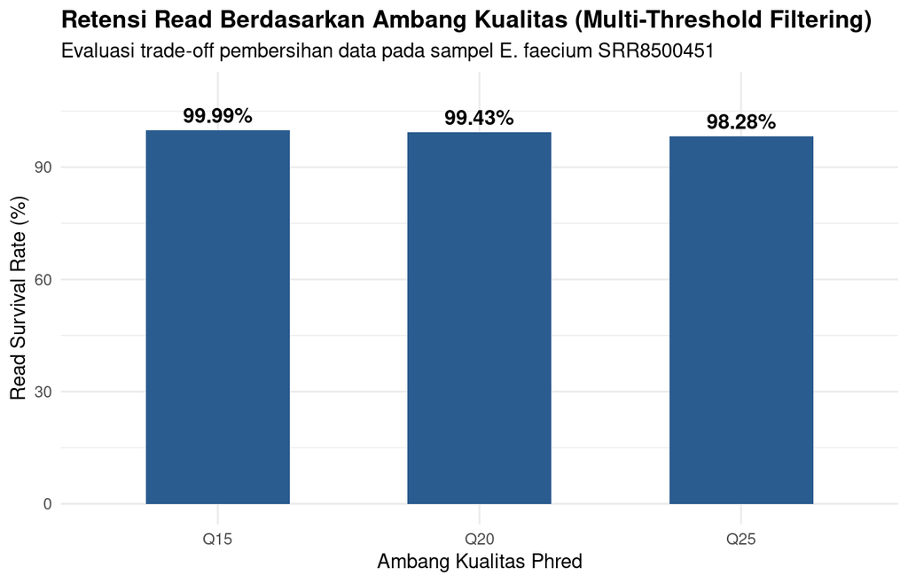

```r
dir.create("reports", showWarnings = FALSE)

# Grafik 1: Survival Rate Multi-Threshold
if (nrow(filt) > 0) {
  p1 <- ggplot(filt, aes(factor(paste0("Q", threshold)), survival_rate)) +
    geom_col(fill = "#2b5c8f", width = 0.55) +
    geom_text(aes(label = paste0(survival_rate, "%")), vjust = -0.5, fontface = "bold", size = 4) +
    scale_y_continuous(limits = c(0, 110)) +
    labs(
      title = "Retensi Read Berdasarkan Ambang Kualitas (Multi-Threshold Filtering)",
      subtitle = "Evaluasi trade-off pembersihan data pada sampel E. faecium SRR8500451",
      x = "Ambang Kualitas Phred",
      y = "Read Survival Rate (%)"
    ) +
    theme_minimal(base_size = 11) +
    theme(plot.title = element_text(face = "bold"))

  ggsave("reports/grafik_survival_rate.png", p1, width = 7, height = 4.5, dpi = 300)
  print(p1)
}
```

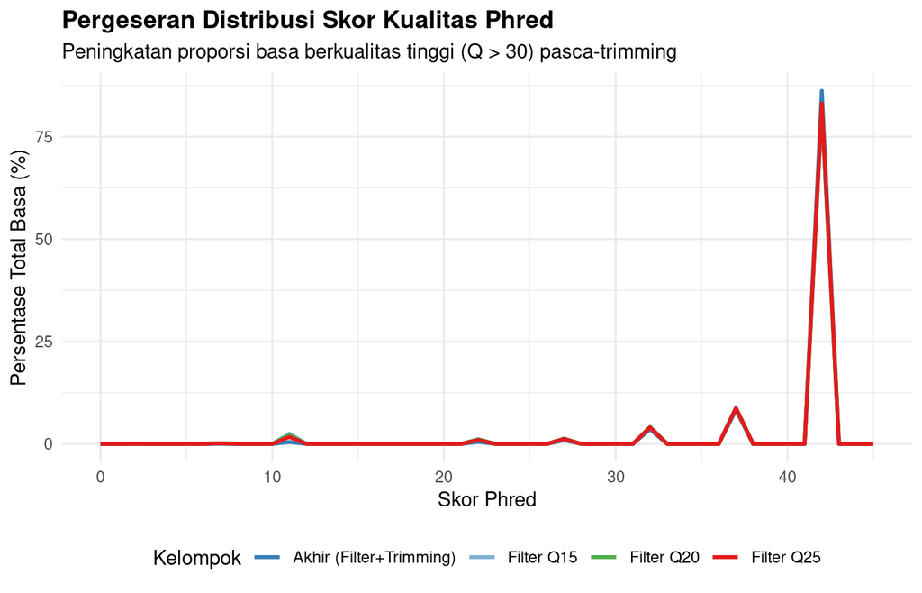

```r
# Grafik 2: Distribusi Skor Phred Sebelum vs Sesudah Trimming
phred_filt_file  <- "results/phred_distribution_filtering.csv"
phred_final_file <- "results/phred_distribution_final.csv"

if (file.exists(phred_filt_file) && file.exists(phred_final_file)) {
  phred_filt  <- read.csv(phred_filt_file)
  phred_final <- read.csv(phred_final_file)

  phred_long <- rbind(
    data.frame(phred = phred_filt$phred_score, persen = phred_filt$Q15, Kelompok = "Filter Q15"),
    data.frame(phred = phred_filt$phred_score, persen = phred_filt$Q20, Kelompok = "Filter Q20"),
    data.frame(phred = phred_filt$phred_score, persen = phred_filt$Q25, Kelompok = "Filter Q25"),
    data.frame(phred = phred_final$phred_score, persen = phred_final$persentase, Kelompok = "Akhir (Filter+Trimming)")
  )

  p2 <- ggplot(phred_long[phred_long$phred <= 45, ], aes(x = phred, y = persen, color = Kelompok)) +
    geom_line(size = 1) +
    scale_color_manual(values = c("Filter Q15" = "#80b1d3", "Filter Q20" = "#4daf4a", "Filter Q25" = "#e41a1c", "Akhir (Filter+Trimming)" = "#377eb8")) +
    labs(
      title = "Pergeseran Distribusi Skor Kualitas Phred",
      subtitle = "Peningkatan proporsi basa berkualitas tinggi (Q > 30) pasca-trimming",
      x = "Skor Phred",
      y = "Persentase Total Basa (%)"
    ) +
    theme_minimal(base_size = 11) +
    theme(plot.title = element_text(face = "bold"), legend.position = "bottom")

  ggsave("reports/grafik_distribusi_phred.png", p2, width = 7, height = 4.5, dpi = 300)
  print(p2)
}
```

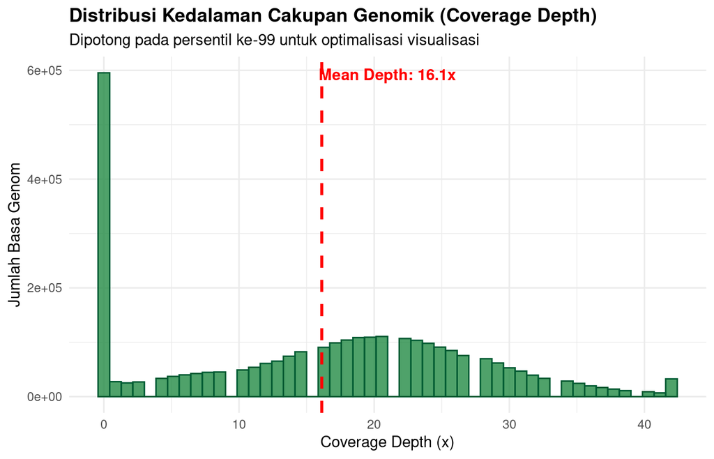

```r
# Grafik 3: Histogram Distribusi Coverage Depth
if (exists("depth_vec") && length(depth_vec) > 0) {
  cap_depth <- quantile(depth_vec, 0.99)
  p3 <- ggplot(data.frame(depth = pmin(depth_vec, cap_depth)), aes(x = depth)) +
    geom_histogram(bins = 50, fill = "#238b45", color = "#005a32", alpha = 0.8) +
    geom_vline(xintercept = mean_depth, color = "red", linetype = "dashed", size = 1) +
    annotate("text", x = mean_depth * 1.3, y = Inf, label = paste0("Mean Depth: ", round(mean_depth, 1), "x"), vjust = 2, color = "red", fontface = "bold") +
    labs(
      title = "Distribusi Kedalaman Cakupan Genomik (Coverage Depth)",
      subtitle = "Dipotong pada persentil ke-99 untuk optimalisasi visualisasi",
      x = "Coverage Depth (x)",
      y = "Jumlah Basa Genom"
    ) +
    theme_minimal(base_size = 11) +
    theme(plot.title = element_text(face = "bold"))

  ggsave("reports/grafik_coverage_depth.png", p3, width = 7, height = 4.5, dpi = 300)
  print(p3)
}
```

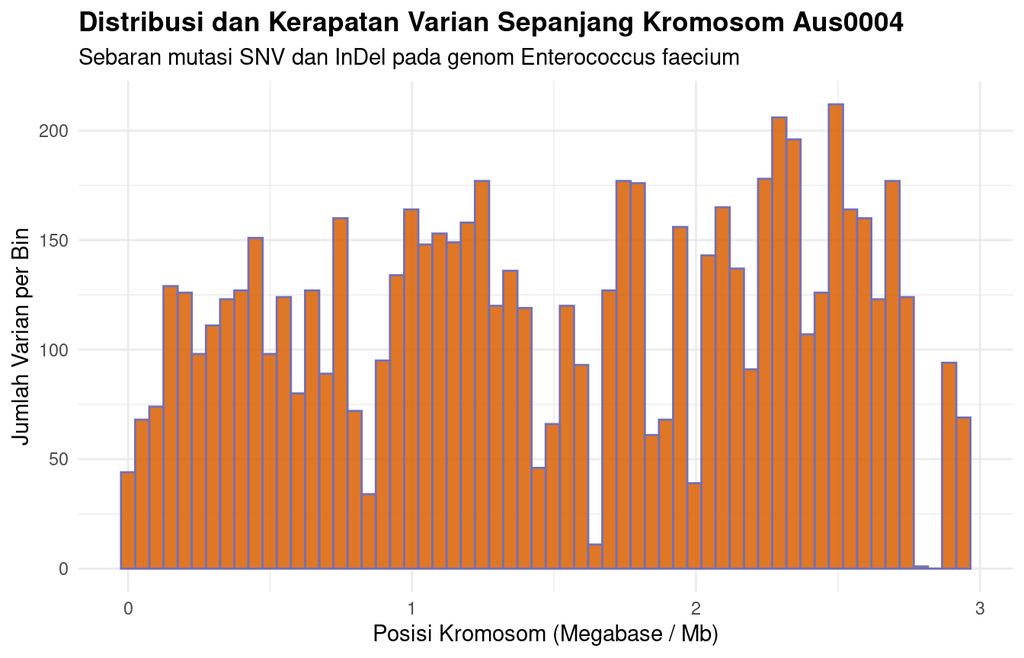

```r
# Grafik 4: Sebaran Lokus Varian Sepanjang Kromosom
if (exists("vcf_raw") && nrow(vcf_raw) > 0) {
  p4 <- ggplot(vcf_raw, aes(x = POS / 1e6)) +
    geom_histogram(bins = 60, fill = "#d95f02", color = "#7570b3", alpha = 0.85) +
    labs(
      title = "Distribusi dan Kerapatan Varian Sepanjang Kromosom Aus0004",
      subtitle = "Sebaran mutasi SNV dan InDel pada genom Enterococcus faecium",
      x = "Posisi Kromosom (Megabase / Mb)",
      y = "Jumlah Varian per Bin"
    ) +
    theme_minimal(base_size = 11) +
    theme(plot.title = element_text(face = "bold"))

  ggsave("reports/grafik_sebaran_varian.png", p4, width = 7, height = 4.5, dpi = 300)
  print(p4)
}
```

```r
cat("Seluruh grafik visualisasi berhasil disimpan di direktori reports/!\n")
```

```
## Seluruh grafik visualisasi berhasil disimpan di direktori reports/!
```